# Gradient Boosting -- Data Prep slides

### Data Prep for Machine Learning

- Categorical Data
- Missing Values

The past two lessons have been taught in service of understanding the basics of how decision trees work, and how they can be combined into more powerful models via boosting.

Today, we'll start using our GradientBoostedRegressor on a more complicated dataset -- our dataset of restaurants, and their daily attendance.

In addition to have more data, it has two additional unique characteristics about it that make it more challenging than the boston housing data:

- It has categorical values
- It has missing data

This class will go over how to handle each of these, with a special eye on what to do when using tree based models.

```python
import pandas as pd
import numpy as np
from sklearn.ensemble import GradientBoostingRegressor
```

```python
# import our dataset -- use your own URL
df = pd.read_csv(r"C:\Users\Jonat\DAT-10-19\ClassMaterial\Unit3\data\restaurants.csv", parse_dates=['visit_date'])
# head should look like this
df.head()
```

|  | id | visit_date | visitors | calendar_date | day_of_week | holiday | genre | area | latitude | longitude | reserve_visitors |
| --- | --- | --- | --- | --- | --- | --- | --- | --- | --- | --- | --- |
| 0 | air_ba937bf13d40fb24 | 2016-01-13 | 25 | 2016-01-13 | Wednesday | 0 | Dining bar | Tōkyō-to Minato-ku Shibakōen | 35.658068 | 139.751599 | NaN |
| 1 | air_ba937bf13d40fb24 | 2016-01-14 | 32 | 2016-01-14 | Thursday | 0 | Dining bar | Tōkyō-to Minato-ku Shibakōen | 35.658068 | 139.751599 | NaN |
| 2 | air_ba937bf13d40fb24 | 2016-01-15 | 29 | 2016-01-15 | Friday | 0 | Dining bar | Tōkyō-to Minato-ku Shibakōen | 35.658068 | 139.751599 | NaN |
| 3 | air_ba937bf13d40fb24 | 2016-01-16 | 22 | 2016-01-16 | Saturday | 0 | Dining bar | Tōkyō-to Minato-ku Shibakōen | 35.658068 | 139.751599 | NaN |
| 4 | air_ba937bf13d40fb24 | 2016-01-18 | 6 | 2016-01-18 | Monday | 0 | Dining bar | Tōkyō-to Minato-ku Shibakōen | 35.658068 | 139.751599 | NaN |

### Model Prep: Handling Missing Values

This is a very common issue in working with data. Luckily tree-based models are the most resilient in handling them, due to their non-assumptive nature.

Key questions to ask yourself when handling missing values:

Is their occurrence random or not?

- If they are random: You want to impute (ie, estimate) them
- If they are not random: You want to encode them with their implied value

### Non-Random Missing Values

This means the missing value has a specific meaning:

- It never happened
- 0
- This thing doesn't exist
- Absence, etc

In this case, it usually is best to fill them in with a single value that represents what that value means.

```python
# let's try for ourselves
df.isnull().sum()
```

```
id                       0
visit_date               0
visitors                 0
calendar_date            0
day_of_week              0
holiday                  0
genre                    0
area                     0
latitude                 0
longitude                0
reserve_visitors    143714
dtype: int64
```

```python
# let's look at value counts
df.reserve_visitors.value_counts().sort_index()
```

```
1.0      1975
2.0     13587
3.0      5376
4.0      8042
5.0      3581
6.0      4627
7.0      6713
8.0      5639
9.0      3738
10.0     6703
11.0     2439
12.0     3677
13.0      744
14.0     1318
15.0     2259
16.0      704
17.0     1459
18.0     1047
20.0      722
21.0     2591
22.0      696
23.0     3564
24.0      613
25.0     3476
27.0      736
28.0      706
30.0     1297
31.0      738
32.0     1182
33.0      771
35.0     1358
36.0     2033
37.0      774
40.0      731
41.0      772
42.0      608
43.0     1372
44.0     1246
46.0     1393
47.0      771
48.0      603
51.0      659
54.0      767
58.0      574
59.0      672
60.0     1411
76.0      767
83.0      575
96.0      588
Name: reserve_visitors, dtype: int64
```

The `reserve_visitors` column is the number of reservations that were made for that day via a booking system. Given that there are no values for `0`, it seems fairly obvious that these are days when there were no reservations being made.

Before we fill in our values, it can be useful to use one additional processing function.

### Denoting A Missing Value

Often if you have a dataset with a lot of missing values, it is helpful to note that a particular value was originally missing. It helps a model "see" whether or not something was there.

In tree based models, this allows them to make more meaningful splits higher up, allowing it to converge with a fewer number of boosting rounds.

```python
# a useful function to help you with this
def denote_null_values(df):
    empty_cols_query = df.isnull().sum() > 0
    empty_df_cols = df.loc[:, empty_cols_query].columns.tolist()
    for col in empty_df_cols:
        col_name = f"{col}_missing"
        df[col_name] = pd.isnull(df[col])
    return df
```

```python
# and we'll apply it here
denote_null_values(df)
```

|  | id | visit_date | visitors | calendar_date | day_of_week | holiday | genre | area | latitude | longitude | reserve_visitors | reserve_visitors_missing |
| --- | --- | --- | --- | --- | --- | --- | --- | --- | --- | --- | --- | --- |
| 0 | air_ba937bf13d40fb24 | 2016-01-13 | 25 | 2016-01-13 | Wednesday | 0 | Dining bar | Tōkyō-to Minato-ku Shibakōen | 35.658068 | 139.751599 | NaN | True |
| 1 | air_ba937bf13d40fb24 | 2016-01-14 | 32 | 2016-01-14 | Thursday | 0 | Dining bar | Tōkyō-to Minato-ku Shibakōen | 35.658068 | 139.751599 | NaN | True |
| 2 | air_ba937bf13d40fb24 | 2016-01-15 | 29 | 2016-01-15 | Friday | 0 | Dining bar | Tōkyō-to Minato-ku Shibakōen | 35.658068 | 139.751599 | NaN | True |
| 3 | air_ba937bf13d40fb24 | 2016-01-16 | 22 | 2016-01-16 | Saturday | 0 | Dining bar | Tōkyō-to Minato-ku Shibakōen | 35.658068 | 139.751599 | NaN | True |
| 4 | air_ba937bf13d40fb24 | 2016-01-18 | 6 | 2016-01-18 | Monday | 0 | Dining bar | Tōkyō-to Minato-ku Shibakōen | 35.658068 | 139.751599 | NaN | True |
| ... | ... | ... | ... | ... | ... | ... | ... | ... | ... | ... | ... | ... |
| 252103 | air_a17f0778617c76e2 | 2017-04-21 | 49 | 2017-04-21 | Friday | 0 | Italian/French | Hyōgo-ken Kōbe-shi Kumoidōri | 34.695124 | 135.197852 | 6.0 | False |
| 252104 | air_a17f0778617c76e2 | 2017-04-22 | 60 | 2017-04-22 | Saturday | 0 | Italian/French | Hyōgo-ken Kōbe-shi Kumoidōri | 34.695124 | 135.197852 | 37.0 | False |
| 252105 | air_a17f0778617c76e2 | 2017-03-26 | 69 | 2017-03-26 | Sunday | 0 | Italian/French | Hyōgo-ken Kōbe-shi Kumoidōri | 34.695124 | 135.197852 | 35.0 | False |
| 252106 | air_a17f0778617c76e2 | 2017-03-20 | 31 | 2017-03-20 | Monday | 1 | Italian/French | Hyōgo-ken Kōbe-shi Kumoidōri | 34.695124 | 135.197852 | 3.0 | False |
| 252107 | air_a17f0778617c76e2 | 2017-04-09 | 26 | 2017-04-09 | Sunday | 0 | Italian/French | Hyōgo-ken Kōbe-shi Kumoidōri | 34.695124 | 135.197852 | 32.0 | False |

252108 rows × 12 columns

```python
# let's save it as a variable
df = denote_null_values(df)
# and fill in the missing ones
df = df.fillna(0)
```

```python
# and let's check now
df.isnull().sum()
```

```
id                          0
visit_date                  0
visitors                    0
calendar_date               0
day_of_week                 0
holiday                     0
genre                       0
area                        0
latitude                    0
longitude                   0
reserve_visitors            0
reserve_visitors_missing    0
dtype: int64
```

### Other Tip:

With tree based models, you can do the equivalent of denoting missing values just by filling them in with an extreme value that's out of range from everything else.

Values used are often -1 (if everything is positive), 999, -999, or something similar.

Most models do **not** allow you to do this, but since trees are insensitive to the scale of your data it gives you very similar results.

### What About Randomly Missing Values?

If values are missing at random, that means their values won't consistently be one value or another. In this case, you need to impute them.

Some basic strategies:

- mean for continuous numbers, mode for categorical values
- you can use the results of a `groupby` to fill them in
- you can use a model (like GradientBoosting!) to predict what they ought to be

### Categorical Data

Lots of datasets have values that are represented as text.

Understanding what to do with these types of numbers is important, and today we're going to go over three different ways of doing this:

- `OneHotEncoding`, or `BinaryEncoding` - Creating a 1, 0 representation for each unique value in a column
- `OrdinalEncoding` - Randomly transforming each categorical value into a unique number
- `TargetEncoding` - Using the average value of the target variable as the basis for each categorical value

  We'll discuss the general pros and cons of each of these methods, as well as items that are specific for tree-based models.

Before we do this -- let's install a useful library for encoding categorical variables:

category encoders: https://contrib.scikit-learn.org/category_encoders/

To use it, type the following into your command line: `pip install category_encoders`

```python
# and import it the following way
import category_encoders as ce
```

### Ordinal Encoding

Ordinal encoding assigns each unique value within a column an integer value. These can either be ordered (ie, Small -> 0, Medium -> 1, Large -> 2), or assigned at random.

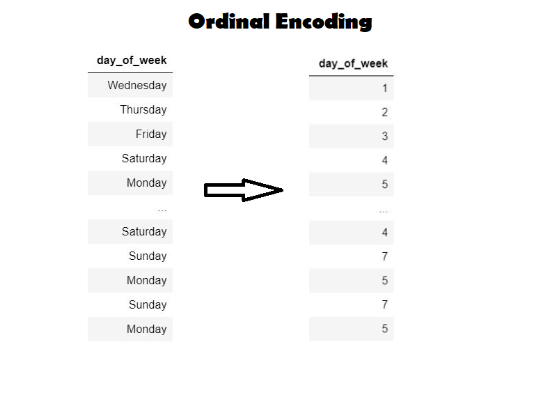

```python
from IPython.display import Image, display

display(Image(filename='assets/ordinal_encoding.png'))
```

```python
# you can do this with category encoders easily with the following function call
# initialize
encoder = ce.OrdinalEncoder()
# and use the fit_transform() method
encoder.fit_transform(df)
```

|  | id | visit_date | visitors | calendar_date | day_of_week | holiday | genre | area | latitude | longitude | reserve_visitors | reserve_visitors_missing |
| --- | --- | --- | --- | --- | --- | --- | --- | --- | --- | --- | --- | --- |
| 0 | 1 | 2016-01-13 | 25 | 1 | 1 | 0 | 1 | 1 | 35.658068 | 139.751599 | 0.0 | True |
| 1 | 1 | 2016-01-14 | 32 | 2 | 2 | 0 | 1 | 1 | 35.658068 | 139.751599 | 0.0 | True |
| 2 | 1 | 2016-01-15 | 29 | 3 | 3 | 0 | 1 | 1 | 35.658068 | 139.751599 | 0.0 | True |
| 3 | 1 | 2016-01-16 | 22 | 4 | 4 | 0 | 1 | 1 | 35.658068 | 139.751599 | 0.0 | True |
| 4 | 1 | 2016-01-18 | 6 | 5 | 5 | 0 | 1 | 1 | 35.658068 | 139.751599 | 0.0 | True |
| ... | ... | ... | ... | ... | ... | ... | ... | ... | ... | ... | ... | ... |
| 252103 | 829 | 2017-04-21 | 49 | 390 | 3 | 0 | 4 | 10 | 34.695124 | 135.197852 | 6.0 | False |
| 252104 | 829 | 2017-04-22 | 60 | 391 | 4 | 0 | 4 | 10 | 34.695124 | 135.197852 | 37.0 | False |
| 252105 | 829 | 2017-03-26 | 69 | 444 | 7 | 0 | 4 | 10 | 34.695124 | 135.197852 | 35.0 | False |
| 252106 | 829 | 2017-03-20 | 31 | 467 | 5 | 1 | 4 | 10 | 34.695124 | 135.197852 | 3.0 | False |
| 252107 | 829 | 2017-04-09 | 26 | 468 | 7 | 0 | 4 | 10 | 34.695124 | 135.197852 | 32.0 | False |

252108 rows × 12 columns

**The basic points behind this:**

- For **practically all** models this can be useful if you have categorical values that have a natural order to them
- Outside of this instance, this is usually **not** a good idea for most models since it does not capture how each unique value might influence the target variable
- Tree based models are uniquely **well suited** for ordinal data, and handle it surprisingly well -- this is because if given enough repetitions tree based models will eventually partition your dataset into its different chunks, regardless of how they're ordered
  - So in practice, this option is usually harmless for tree based models, but you might need to use additional boosting rounds to eventually separate the values into their naturally occurring clusterings

### OneHot Encoding

- Creates a binary 1, 0 representation for each unique value in a column
- It does this by creating a separate column for each unique value within a column

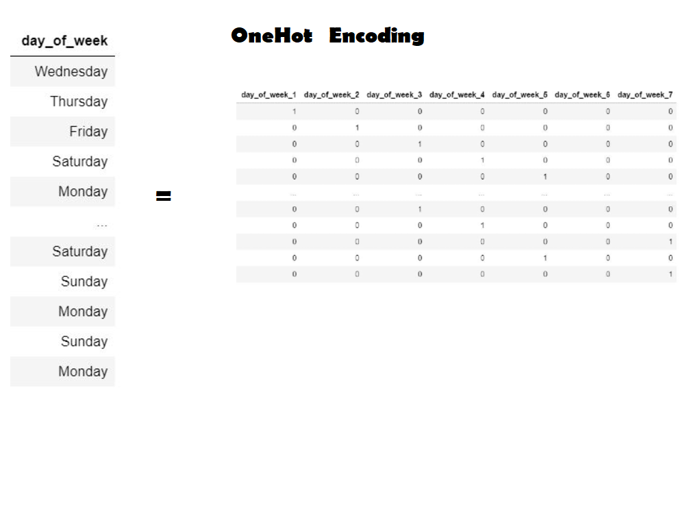

```python
from IPython.display import Image, display

display(Image(filename='assets/onehot_encoding.png'))
```

**The basic points behind this:**

- This is probably the standard way of encoding categorical features for most models
- Provides the most resolution with respect to how much each unique value aligns with the target variable

**Bad Things:**

- This can add a **lot** of columns to your dataset. For some models this makes fitting either more time consuming or less reliable, and sometimes to the point that it will not converge at all
- For variable values that don't occur frequently, this can make the values for this column **less reliable**, ie, if there's a categorical value that only occurs 30 times in a 250K row dataset, the numerical sparsity means it can be difficult to generate a useful statistical signal
- For tree based models -- categorical columns with lots of unique values can make for **very uneven splits**, which can make it difficult for categorical values to get their proper due in model fitting

#### The Bottom Line

- For tree based models, there is surprisingly **little** difference between these two
- Somewhat paradoxically, ordinal encoding is often more reliable -- fitting times can be **much faster** if there are lots of unique values
- Ordinal encoding will more likely give you lots of samples on each side of a split, which agrees with how trees fit their data

However.....

- If you want insight into the **impact** of a particular value on its target, onehot encoding will give you more granular insight
- For example, a `feature importance` score will not give unique values for different categories in an ordinal column
  - So if model insight is of the utmost importance, then one hot encoding can be more important

```python
# OneHot Encoding in category_encoders
ohe = ce.OneHotEncoder()
ohe.fit_transform(df)
```

|  | id_1 | id_2 | id_3 | id_4 | id_5 | id_6 | id_7 | id_8 | id_9 | id_10 | ... | area_98 | area_99 | area_100 | area_101 | area_102 | area_103 | latitude | longitude | reserve_visitors | reserve_visitors_missing |
| --- | --- | --- | --- | --- | --- | --- | --- | --- | --- | --- | --- | --- | --- | --- | --- | --- | --- | --- | --- | --- | --- |
| 0 | 1 | 0 | 0 | 0 | 0 | 0 | 0 | 0 | 0 | 0 | ... | 0 | 0 | 0 | 0 | 0 | 0 | 35.658068 | 139.751599 | 0.0 | True |
| 1 | 1 | 0 | 0 | 0 | 0 | 0 | 0 | 0 | 0 | 0 | ... | 0 | 0 | 0 | 0 | 0 | 0 | 35.658068 | 139.751599 | 0.0 | True |
| 2 | 1 | 0 | 0 | 0 | 0 | 0 | 0 | 0 | 0 | 0 | ... | 0 | 0 | 0 | 0 | 0 | 0 | 35.658068 | 139.751599 | 0.0 | True |
| 3 | 1 | 0 | 0 | 0 | 0 | 0 | 0 | 0 | 0 | 0 | ... | 0 | 0 | 0 | 0 | 0 | 0 | 35.658068 | 139.751599 | 0.0 | True |
| 4 | 1 | 0 | 0 | 0 | 0 | 0 | 0 | 0 | 0 | 0 | ... | 0 | 0 | 0 | 0 | 0 | 0 | 35.658068 | 139.751599 | 0.0 | True |
| ... | ... | ... | ... | ... | ... | ... | ... | ... | ... | ... | ... | ... | ... | ... | ... | ... | ... | ... | ... | ... | ... |
| 252103 | 0 | 0 | 0 | 0 | 0 | 0 | 0 | 0 | 0 | 0 | ... | 0 | 0 | 0 | 0 | 0 | 0 | 34.695124 | 135.197852 | 6.0 | False |
| 252104 | 0 | 0 | 0 | 0 | 0 | 0 | 0 | 0 | 0 | 0 | ... | 0 | 0 | 0 | 0 | 0 | 0 | 34.695124 | 135.197852 | 37.0 | False |
| 252105 | 0 | 0 | 0 | 0 | 0 | 0 | 0 | 0 | 0 | 0 | ... | 0 | 0 | 0 | 0 | 0 | 0 | 34.695124 | 135.197852 | 35.0 | False |
| 252106 | 0 | 0 | 0 | 0 | 0 | 0 | 0 | 0 | 0 | 0 | ... | 0 | 0 | 0 | 0 | 0 | 0 | 34.695124 | 135.197852 | 3.0 | False |
| 252107 | 0 | 0 | 0 | 0 | 0 | 0 | 0 | 0 | 0 | 0 | ... | 0 | 0 | 0 | 0 | 0 | 0 | 34.695124 | 135.197852 | 32.0 | False |

252108 rows × 1438 columns

### Common Problem: Categorical Columns That Have Lots of Unique Values

Very common issue is you have a column with categorical values that is very important, but has lots of unique values, making onehot encoding problematic.

Zip codes, medical billing codes, customer ids, etc.

The fancy term for this scenario is a **high cardinality column**

In our example, the restaurant id is a good example. It's probably quite important, but with 800+ unique values, it will be difficult to fit a model on onehot encoded variables for various reasons. Long fitting times, and tree based models will be slow to split on them, even if it's an important variable.

So, let's take a look at another technique that's useful for this scenario.